# In Class Exercise (Partial Solution)

The birth weight of a baby is of interest to health officials since many studies have shown possible links between weight and conditions later in life, such as obesity or diabetes. The data set `Girls2004` consists of a random sample of 40 baby girls born in Alaska and 40 baby girls born in Wyoming. These babies also had a gestation period of at least 37 weeks and were single births.

Import the data `Girls2004` available from https://raw.githubusercontent.com/alanarnholt/STT3850/gh-pages/DataCSV/Girls2004.csv.

```r
site <- "https://raw.githubusercontent.com/alanarnholt/STT3850/gh-pages/DataCSV/Girls2004.csv"
Girls <- read.csv(file=url(site))
head(Girls)
```

```
##   ID State MothersAge Smoker Weight Gestation
## 1  1    WY      15-19     No   3085        40
## 2  2    WY      35-39     No   3515        39
## 3  3    WY      25-29     No   3775        40
## 4  4    WY      20-24     No   3265        39
## 5  5    WY      25-29     No   2970        40
## 6  6    WY      20-24     No   2850        38
```

- Perform some exploratory data analysis and obtain summary statistics on the weights of baby girls born in Wyoming and Alaska (do separate analyses for each state).

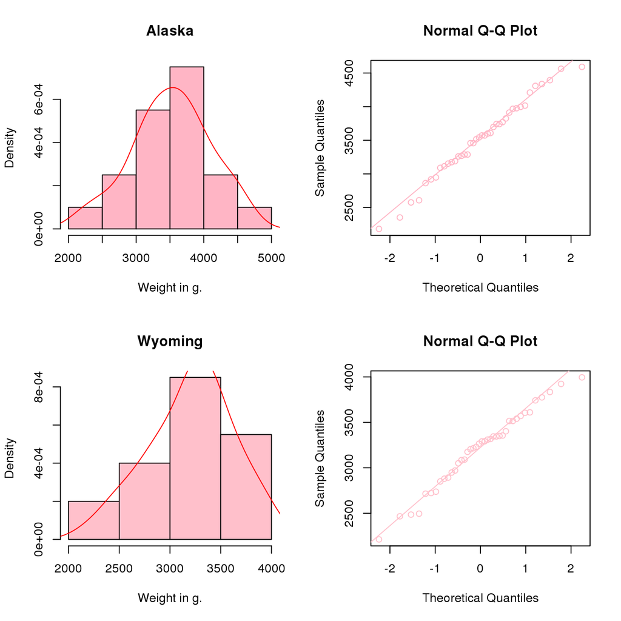

```r
opar <- par(no.readonly = TRUE)
par(mfrow=c(2, 2))
hist(Girls$Weight[Girls$State=="AK"], col = "pink1", breaks = "Scott", xlab = "Weight in g.", main = "Alaska", freq= FALSE)
lines(density(Girls$Weight[Girls$State=="AK"]), col ="red")
qqnorm(Girls$Weight[Girls$State=="AK"], col = "pink1")
qqline(Girls$Weight[Girls$State=="AK"], col = "pink1")
hist(Girls$Weight[Girls$State=="WY"], col = "pink", breaks = "Scott", xlab = "Weight in g.", main = "Wyoming", freq= FALSE)
lines(density(Girls$Weight[Girls$State=="WY"]), col ="red")
qqnorm(Girls$Weight[Girls$State=="WY"], col = "pink")
qqline(Girls$Weight[Girls$State=="WY"], col = "pink")
```

```r
par(opar)
```

Another approach is to use `lattice`.

```r
require(lattice)
```

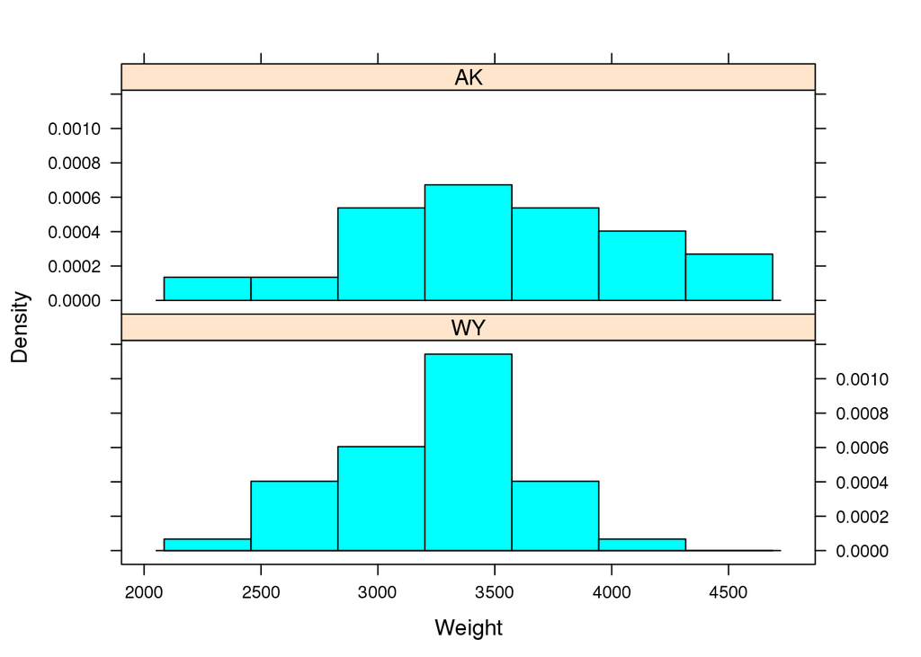

```r
histogram(~Weight|State, data = Girls, layout=c(1, 2), as.table = TRUE, type = "density")
```

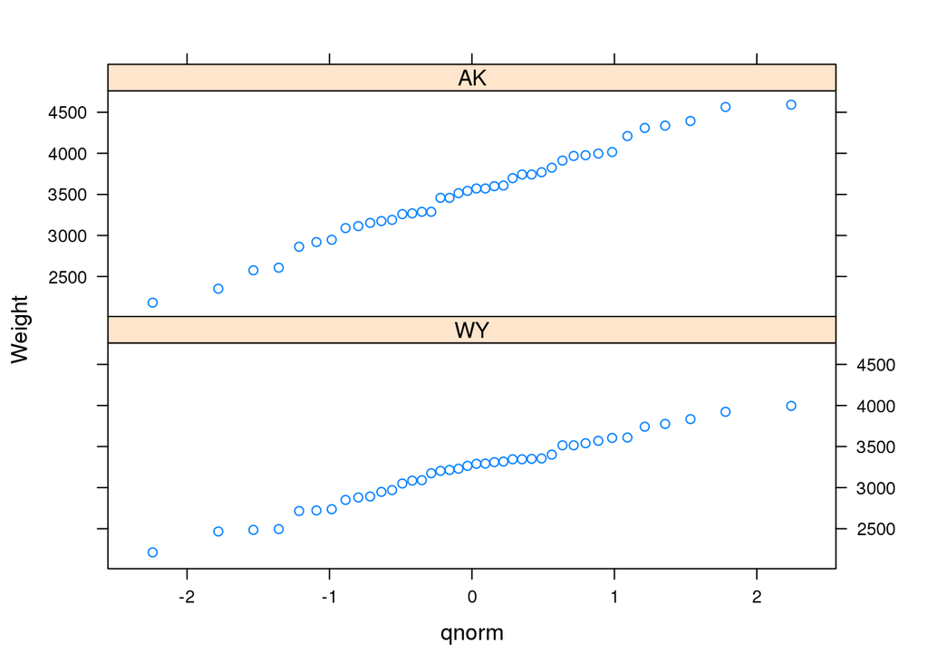

```r
qqmath(~Weight|State, data = Girls, layout=c(1, 2), as.table = TRUE)
```

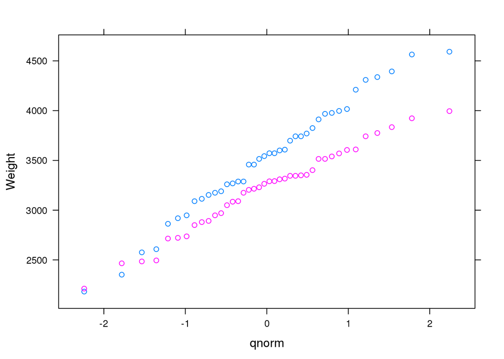

```r
qqmath(~Weight, group = State, data = Girls)
```

A third approach is to use `ggplot2`. (This is my preference.)

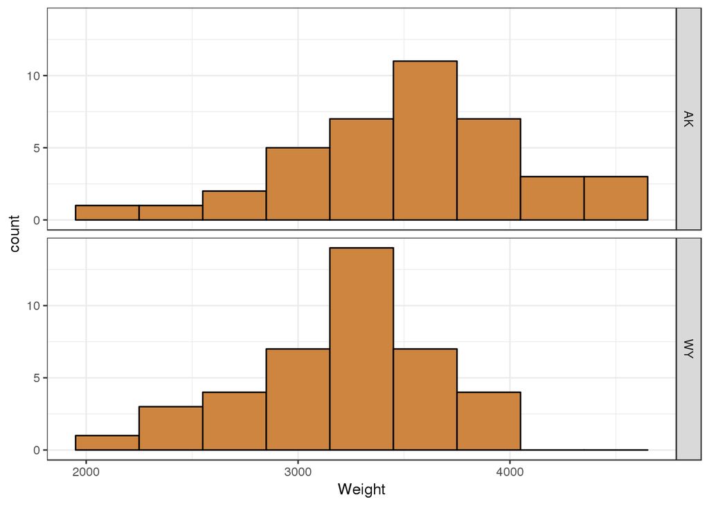

```r
require(ggplot2)
p <- ggplot(data = Girls, aes(x = Weight)) + geom_histogram(binwidth = 300, fill = "peru", color = "black") + facet_grid(State ~ .)
p + theme_bw()
```

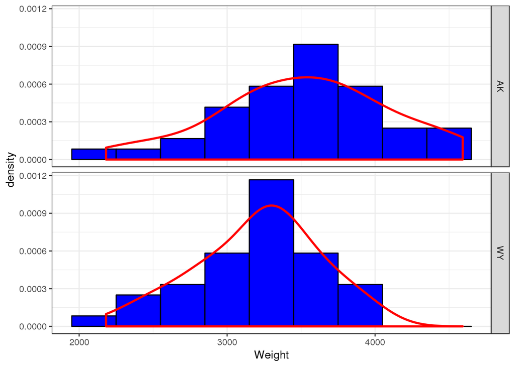

```r
p1 <- ggplot(data = Girls, aes(x = Weight)) + geom_histogram(aes(y = ..density..), binwidth = 300, fill = "blue", color = "black") + facet_grid(State ~ .) + geom_density(color = "red", size = 1)
p1 + theme_bw()
```

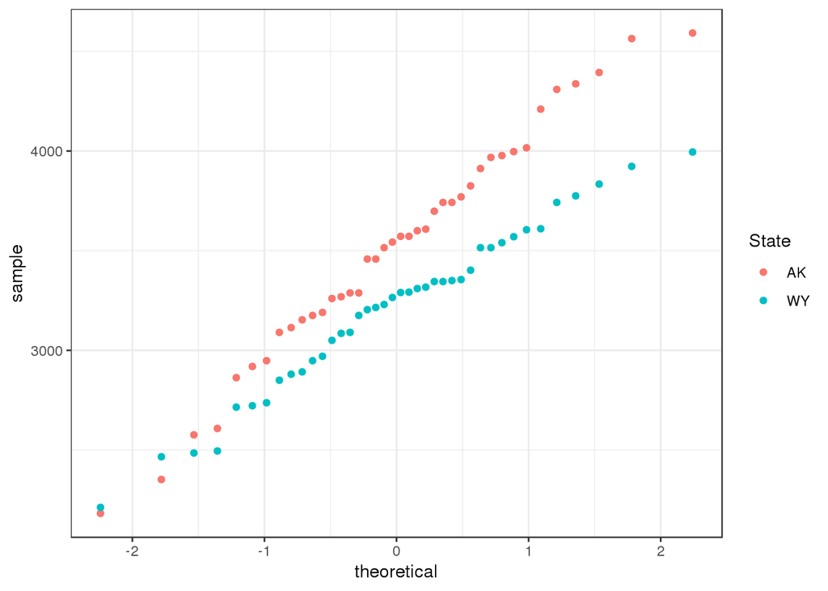

```r
p2 <- ggplot(data = Girls, aes(sample = Weight, color = State)) + stat_qq()
p2 + theme_bw()
```

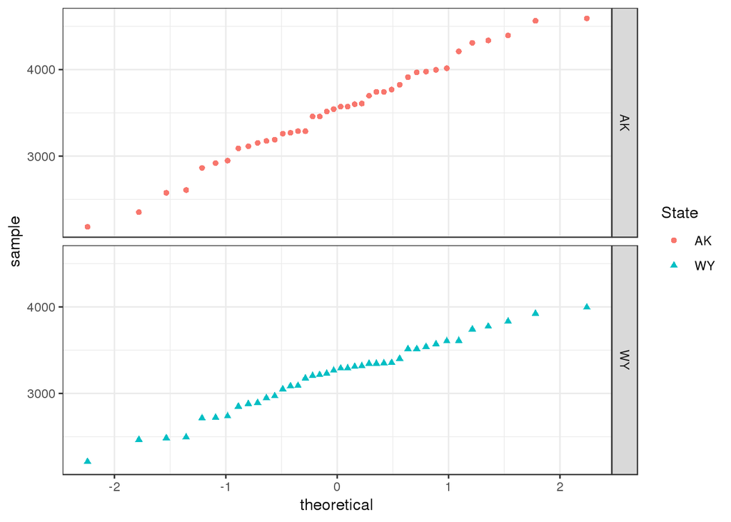

```r
ggplot(data = Girls, aes(sample = Weight, shape = State, color = State)) + stat_qq() + facet_grid(State~.) + theme_bw()
```

## Graphs are fun!

```r
with(data = Girls,
tapply(Weight, State, mean))
```

```
     AK      WY
3516.35 3207.90
```

```r
tapply(Girls$Weight, Girls$State, sd)
```

```
      AK       WY
578.8336 418.3184
```

```r
AK.weight <- subset(Girls, select = Weight, subset = State == "AK", drop = TRUE)
WY.weight <- subset(Girls, select = Weight, subset = State == "WY", drop = TRUE)
c(mean(AK.weight), sd(AK.weight), mean(WY.weight), sd(WY.weight))
```

```
[1] 3516.3500  578.8336 3207.9000  418.3184
```

> ANSWER: The mean and standard deviation of weight for baby girls born in Alaska is 3516.35 and 578.8336438, respectively. The mean and standard deviation of weight for baby girls born in Wyoming is 3207.9 and 418.3184163, respectively.
- Bootstrap the difference in means, plot the distribution, and give summary statistics. Obtain a 95% bootstrap percentile confidence interval and interpret this interval.

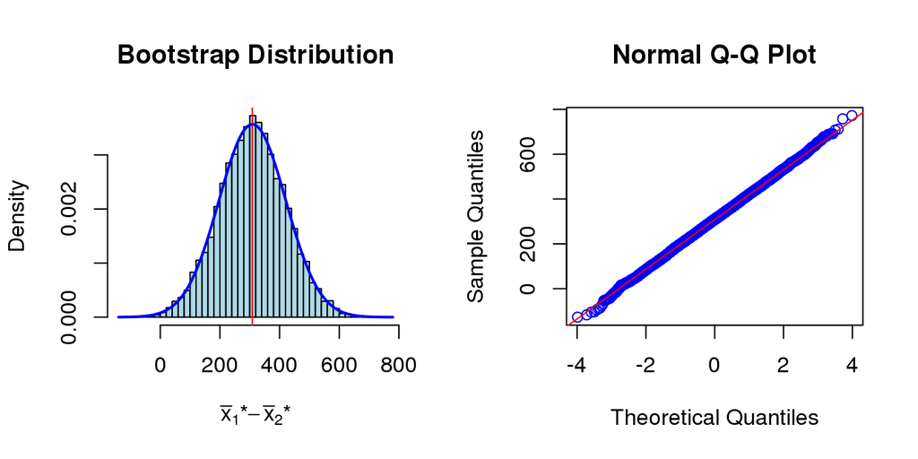

```r
B <- 15000
mean.diff <- numeric(B)
for(i in 1:B){
  AK <- sample(AK.weight, size = sum(!is.na(AK.weight)), replace = TRUE)
  WY <- sample(WY.weight, size = sum(!is.na(WY.weight)), replace = TRUE)
  mean.diff[i] <- mean(AK) - mean(WY)
}
opar <- par(no.readonly = TRUE)
par(mfrow=c(1, 2))
hist(mean.diff, breaks = "Scott", col = "lightblue", main = "Bootstrap Distribution", xlab = substitute(paste(bar(x)[1],"*", - bar(x)[2],"*")), freq= FALSE)
abline(v = mean(AK.weight) - mean(WY.weight), col = "red")
curve(dnorm(x, mean(mean.diff), sd(mean.diff)), col ="blue", add= TRUE, lwd = 2)
qqnorm(mean.diff, col ="blue")
qqline(mean.diff, col = "red")
```

```r
par(opar)
BIAS <- mean(mean.diff) - (mean(AK.weight) - mean(WY.weight))
BIAS
```

```
## [1] 0.3141883
```

```r
CI <- quantile(mean.diff, prob = c(.025, .975))
CI
```

```
##      2.5%     97.5%
##  88.59937 528.65063
```

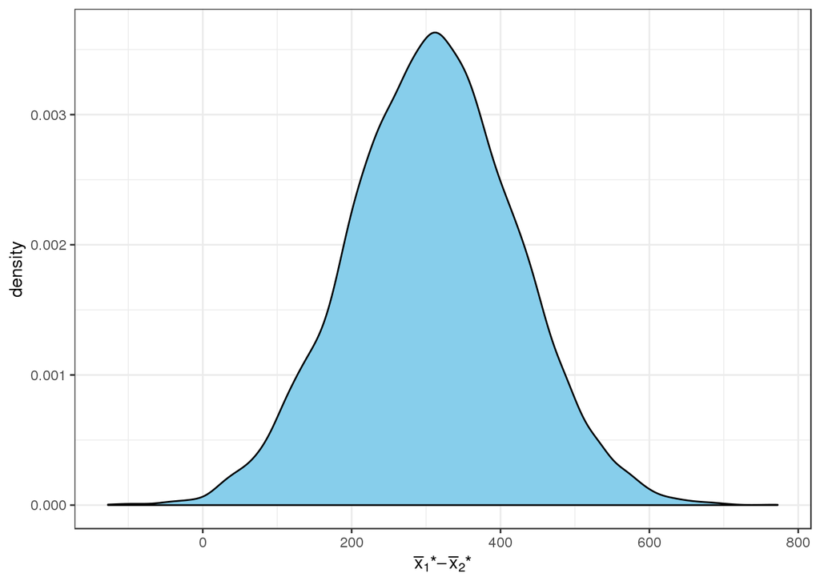

```r
ggplot(data = data.frame(x = mean.diff), aes(x = x)) + geom_density(fill = "skyblue") + labs(x = substitute(paste(bar(x)[1],"*", - bar(x)[2],"*"))) + theme_bw()
```

> ANSWER: The mean of the bootstrap distribution of the difference of means ($\hat{\mu}_{\bar{x}^*_1 - \bar{x}^*_2}$) is 308.7641883 while the standard error of the bootstrap distribution of means ($\hat{\sigma}_{\bar{x}^*_1 - \bar{x}^*_2}$) is 111.8471119. We are 95% confident that the mean weight of baby girls born in Alaska are 88.599375 to 528.650625 grams greater than baby girls born in Wyoming.
- What is the bootstrap estimate of the bias? What fraction of the bootstrap standard error does it represent?

> ANSWER: The bootstrap estimate of the bias $(Bias_{boot}[\bar{x}^*_1 - \bar{x}^*_2] = E[\bar{x}^*_1 - \bar{x}^*_2] - [\bar{x}_1 - \bar{x}_2])$ is 0.3141883. The $Bias_{boot}[\bar{x}^*_1 - \bar{x}^*_2]$ represents 0.2809088% of the standard error of the bootstrap.
- Conduct a permutation test to calculate the difference in mean weights and state your conclusion.

```r
ANS <- tapply(Girls$Weight, Girls$State, mean)
ANS
```

```
##      AK      WY
## 3516.35 3207.90
```

```r
obs.mean.diff <- ANS[1] - ANS[2]
names(obs.mean.diff) <- NULL
obs.mean.diff
```

```
## [1] 308.45
```

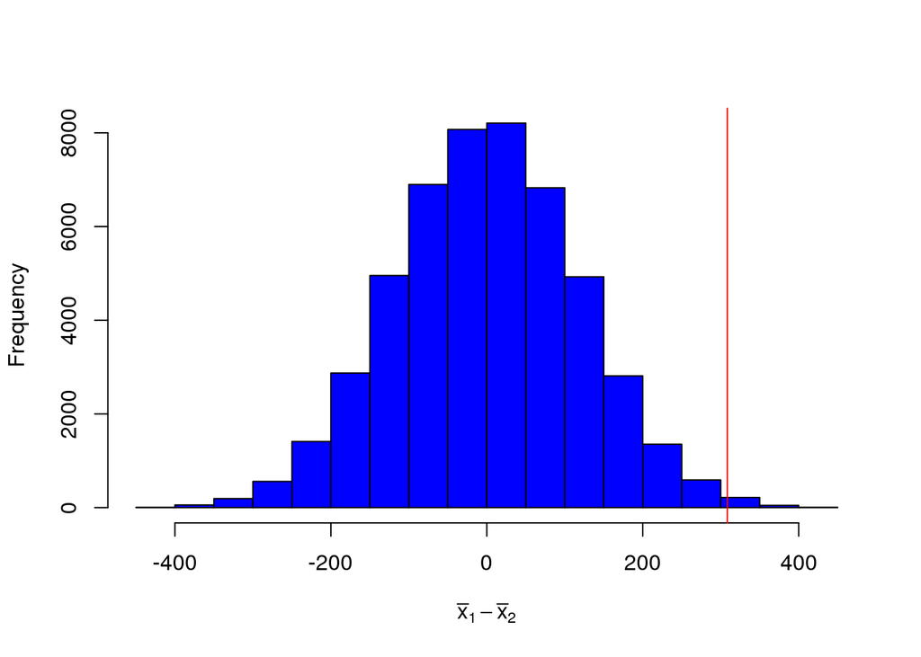

```r
R <- 50000
Weight <- subset(Girls, select = Weight, drop = TRUE)
result <- numeric(R)  # space to save the random differences
for (i in 1:R){
  # sample of size 40, from 1 to 80, without replacement
  index <- sample(80, size = 40, replace = FALSE)
  result[i] <- mean(Weight[index]) - mean(Weight[-index])
}
hist(result, col = "blue", main = "", xlab = expression(bar(x)[1]- bar(x)[2]))
abline(v = obs.mean.diff, col = "red")
```

```r
pvalue <- (sum(abs(result) >= abs(obs.mean.diff) + 1))/(R + 1) # p-value
pvalue  # results will vary
```

```
## [1] 0.007939841
```

The *p*-value for testing $H_0: \mu_{AK} = \mu_{WY}$ versus $H_A: \mu_{AK} \neq \mu_{WY}$ is 0.0079398. The small *p*-value suggests that the mean weight of babies born in Alaska is not the same as the mean weight of babies born in Wyoming.

- For what population(s) if any, does this conclusion hold? Explain.